# Exploratory Data Analysis: Nephrology

02-20-2026

# 1. Setup & Data Import

```r
library(tidyverse)
# Load data and automatically clean column names
nephrology_data <- read_csv("nephrology_data.xlsx - Option 1.csv", show_col_types = FALSE)
colnames(nephrology_data)
```

```
##  [1] "Sound Bite Text"                     "Title"
##  [3] "Source Name"                         "Post"
##  [5] "Paid"                                "Media"
##  [7] "Domain"                              "Sentiment"
##  [9] "Published Date (GMT-04:00) New York" "Author Gender"
## [11] "User Name"                           "Richness"
```

```r
str(nephrology_data)
```

```
## spc_tbl_ [102 × 12] (S3: spec_tbl_df/tbl_df/tbl/data.frame)
##  $ Sound Bite Text                    : chr [1:102] "Those are very bad numbers, and I have never had out of range renal labs at this point…so I'm most certainly lo"| __truncated__ "Currently, I am in stage 4 CKD with IgAN and am on the cusp of dialysis and transplant: what has been incredibl"| _…
##  $ Title                              : chr [1:102] "question about levels over 100" "My friend just got diagnosed" "My friend just got diagnosed" "My friend just got diagnosed" ...
##  $ Source Name                        : chr [1:102] "r/kidneydisease" "r/IgANephropathy" "r/IgANephropathy" "r/IgANephropathy" ...
##  $ Post                               : chr [1:102] "Replies and Comments" "Replies and Comments" "Replies and Comments" "Replies and Comments" ...
##  $ Paid                               : chr [1:102] "No" "No" "No" "No" ...
##  $ Media                              : chr [1:102] "Link" "No Media" "No Media" "No Media" ...
##  $ Domain                             : chr [1:102] "reddit.com" "reddit.com" "reddit.com" "reddit.com" ...
##  $ Sentiment                          : chr [1:102] "Neutrals" "Neutrals" "Neutrals" "Neutrals" ...
##  $ Published Date (GMT-04:00) New York: chr [1:102] "7/22/2023" "7/28/2023" "7/28/2023" "7/28/2023" ...
##  $ Author Gender                      : chr [1:102] "Unknown" "Unknown" "Unknown" "Unknown" ...
##  $ User Name                          : chr [1:102] "user_169861.440112387" "user_10500000" "user_10500000" "user_10500000" ...
##  $ Richness                           : num [1:102] 5 3 3 4 2 8 2 6 8 8 ...
##  - attr(*, "spec")=
##   .. cols(
##   ..   `Sound Bite Text` = col_character(),
##   ..   Title = col_character(),
##   ..   `Source Name` = col_character(),
##   ..   Post = col_character(),
##   ..   Paid = col_character(),
##   ..   Media = col_character(),
##   ..   Domain = col_character(),
##   ..   Sentiment = col_character(),
##   ..   `Published Date (GMT-04:00) New York` = col_character(),
##   ..   `Author Gender` = col_character(),
##   ..   `User Name` = col_character(),
##   ..   Richness = col_double()
##   .. )
##  - attr(*, "problems")=<externalptr>
```

```r
glimpse(nephrology_data)
```

```
## Rows: 102
## Columns: 12
## $ `Sound Bite Text`                     <chr> "Those are very bad numbers, and…
## $ Title                                 <chr> "question about levels over 100"…
## $ `Source Name`                         <chr> "r/kidneydisease", "r/IgANephrop…
## $ Post                                  <chr> "Replies and Comments", "Replies…
## $ Paid                                  <chr> "No", "No", "No", "No", "No", "N…
## $ Media                                 <chr> "Link", "No Media", "No Media", …
## $ Domain                                <chr> "reddit.com", "reddit.com", "red…
## $ Sentiment                             <chr> "Neutrals", "Neutrals", "Neutral…
## $ `Published Date (GMT-04:00) New York` <chr> "7/22/2023", "7/28/2023", "7/28/…
## $ `Author Gender`                       <chr> "Unknown", "Unknown", "Unknown",…
## $ `User Name`                           <chr> "user_169861.440112387", "user_1…
## $ Richness                              <dbl> 5, 3, 3, 4, 2, 8, 2, 6, 8, 8, 5,…
```

# 2. Data Cleaning & Summaries

```r
data_clean <- nephrology_data %>%
  rename(
    sound_bite = `Sound Bite Text`,
    title = Title,
    source_name = `Source Name`,
    post_text = Post,
    paid = Paid,
    media = Media,
    domain = Domain,
    sentiment = Sentiment,
    author_gender = `Author Gender`,
    user_name = `User Name`,
    richness = Richness
  )
```

```r
avg_sentiment <- mean(data_clean$sentiment, na.rm = TRUE)
avg_richness  <- mean(data_clean$richness, na.rm = TRUE)

upper_half_data <- data_clean %>%
  filter(sentiment > avg_sentiment,
         richness > avg_richness)

lower_half_data <- data_clean %>%
  filter(sentiment < avg_sentiment |
         richness < avg_richness)

nrow(lower_half_data)
```

```
## [1] 58
```

```r
upper_half_data
```

```
## # A tibble: 0 × 12
## # ℹ 12 variables: sound_bite <chr>, title <chr>, source_name <chr>,
## #   post_text <chr>, paid <chr>, media <chr>, domain <chr>, sentiment <chr>,
## #   Published Date (GMT-04:00) New York <chr>, author_gender <chr>,
## #   user_name <chr>, richness <dbl>
```

```r
lower_half_data
```

```
## # A tibble: 58 × 12
##    sound_bite           title source_name post_text paid  media domain sentiment
##    <chr>                <chr> <chr>       <chr>     <chr> <chr> <chr>  <chr>
##  1 "Currently, I am in… My f… r/IgANephr… Replies … No    No M… reddi… Neutrals
##  2 "Hello OP, I can re… My f… r/IgANephr… Replies … No    No M… reddi… Neutrals
##  3 "My best advice to … My f… r/IgANephr… Replies … No    No M… reddi… Neutrals
##  4 "This too shall pas… My f… r/IgANephr… Replies … No    No M… reddi… Neutrals
##  5 "Insomnia, weight g… Side… r/IgANephr… Original  No    No M… reddi… Neutrals
##  6 "In my head, I do f… Poss… r/IgANephr… Original  No    No M… reddi… Neutrals
##  7 "We were planning o… Poss… r/IgANephr… Original  No    No M… reddi… Neutrals
##  8 "Hey everyone just … Diag… r/IgANephr… Original  No    No M… reddi… Neutrals
##  9 "Hey everyone just … Diag… r/IgANephr… Original  No    No M… reddi… Neutrals
## 10 "You are vitamin D … Plea… r/AskDocs   Replies … No    No M… reddi… Neutrals
## # ℹ 48 more rows
## # ℹ 4 more variables: `Published Date (GMT-04:00) New York` <chr>,
## #   author_gender <chr>, user_name <chr>, richness <dbl>
```

# 3. Exploratory Visualizations

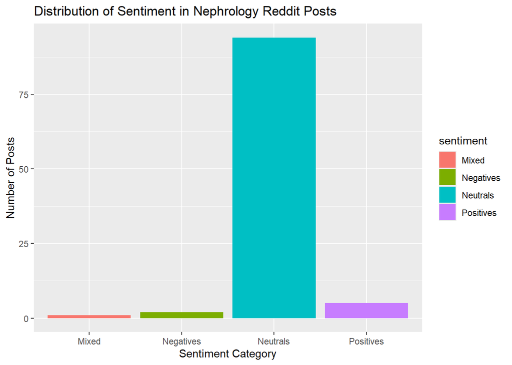

```r
ggplot(data_clean, aes(x = sentiment, fill = sentiment)) +
  geom_bar() +
  labs(
    title = "Distribution of Sentiment in Nephrology Reddit Posts",
    x = "Sentiment Category",
    y = "Number of Posts"
  )
```

**What we are looking for** I wanted to understand the overall tone of nephrology Reddit posts by counting how many posts fall into each sentiment category. **What does the plot reveal?** The bar chart shows that almost all posts are labeled Neutral. There are only a few Positive posts, very few Negative posts, and only one Mixed post. **Surprising or interesting trends?** It is surprising that Neutral posts make up the large majority of the dataset. This suggests that most discussions are informational rather than emotional. Strong opinions appear less often. # Richness vs. Sentiment

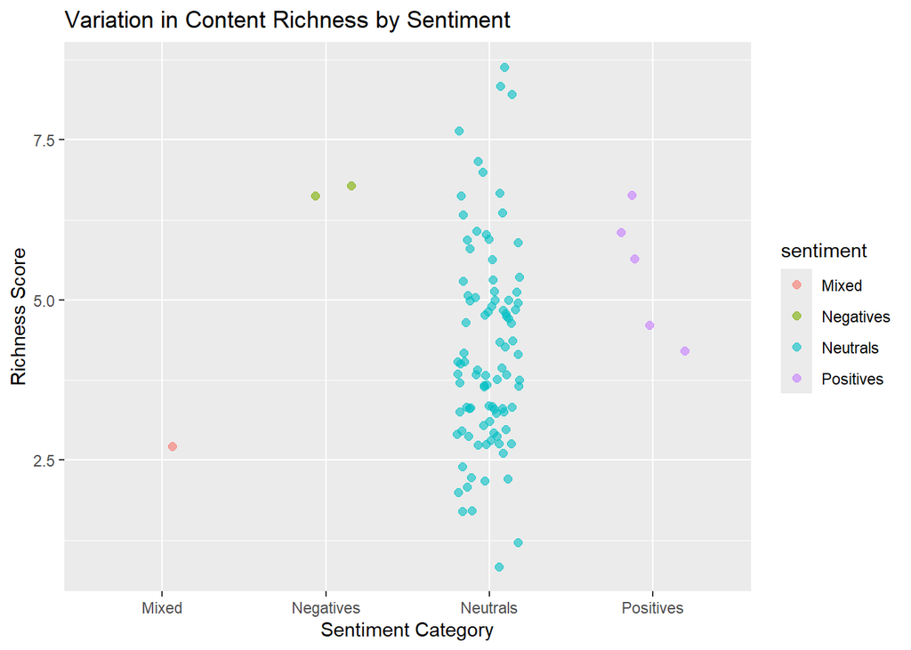

```r
ggplot(data_clean, aes(x = sentiment, y = richness, color = sentiment)) +
  geom_jitter(width = 0.2, alpha = 0.6, size = 2) +
  labs(
    title = "Variation in Content Richness by Sentiment",
    x = "Sentiment Category",
    y = "Richness Score"
  )
```

**What we are looking for** I wanted to see if posts with different sentiments vary in how detailed they are. **What the plot reveals** Since most posts are Neutral, most richness scores fall under that category. The few Positive and Negative posts show some variation, but there are not enough of them to see a strong pattern. **Notes on surprising or interesting trends** There is no clear difference in richness between sentiment categories. This may be because the dataset is heavily dominated by Neutral posts. # Richness Distribution Density Plot

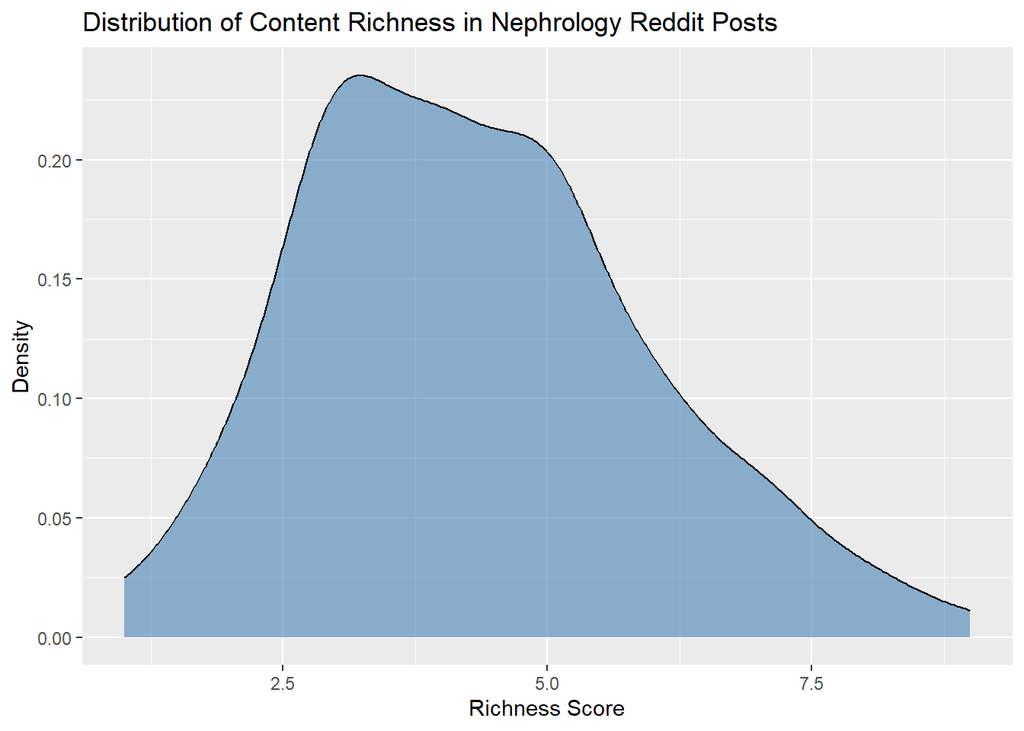

```r
ggplot(data_clean, aes(x = richness)) +
  geom_density(fill = "steelblue", alpha = 0.6) +
  labs(
    title = "Distribution of Content Richness in Nephrology Reddit Posts",
    x = "Richness Score",
    y = "Density"
  )
```

**Explain what you’re looking for** I wanted to understand how detailed posts are overall. **Discuss what the plot reveals** The average richness score is about 4.3. Most posts fall between 3 and 5. Very few posts are extremely short (1–2) or extremely detailed (above 7). **Note surprising or interesting trends** The distribution shows that most posts are moderately detailed. This suggests that users provide helpful explanations but usually do not write very long posts.

# 4. Insights & Questions

**Describe key patterns and relationships you found** The dataset is strongly dominated by Neutral sentiment (94 out of 102 posts). Positive and Negative posts are rare. Most posts have a moderate richness level. There is no strong visible relationship between sentiment and richness.

**Propose 2-3 follow-up questions for deeper investigation** 1 - Why are so many posts labeled Neutral, is the sentiment tool too broad? 2 - Do certain subreddits have more Positive or Negative posts? 3 - Do more detailed posts receive more replies or engagement?

**Connect findings to potential group research directions** Explore differences across subreddit sources. Look into how richness relates to user behavior.

# 5. Reflection

A challenge was that the dataset is unbalanced. Since most posts are Neutral, it is harder to compare sentiment groups. Another was interpreting what “richness” truly represents without more context.